# Assignment 1

gg

Oct 4, 2017

# Assignment 1

Please hand this in as an .Rmd document, and I will convert it to html or pdf for marking

You will be graded for your comments, I need to know that you understand the basics of R and how the code is working. You are really writing for your future self, so it should be easy to separate the code from the comments. Place general comments about what you are trying to accomplish outside of the R code itself.

I know that part 4 will be a challenge, but it can be done simply using a for loop. You first have to decide exactly what it is you want to do—this is almost always the most difficult part.

You may not include any R functions or packages that are not part of base R.

I will schedule a 5 minute interview with each of you to go over the comments and code. As noted in class, this will be graded on a pass-fail basis. If you do the assignment yourself, you will pass.

# functions and loops in R

loops and functions are standard fare in R programs. Another is the if-else statement that is used to do something conditionally. For example:

explanation of if-else function in R is here: http://www.programiz.com/r-programming/if-else-statement

## part 1: commment this code. Make sure to use your own wording

```r
for(i in seq(1,29,3)){
    if ( (i %/% 2) %% 2 == 0) {
        print( c(i, i %/% 2, "is even"))
    } else if ((i %/% 2) %% 2 != 0) {
        print(c(i, i %/% 2, "is odd"))
    }
}
```

```
## [1] "1"       "0"       "is even"
## [1] "4"       "2"       "is even"
## [1] "7"      "3"      "is odd"
## [1] "10"     "5"      "is odd"
## [1] "13"      "6"       "is even"
## [1] "16"      "8"       "is even"
## [1] "19"     "9"      "is odd"
## [1] "22"     "11"     "is odd"
## [1] "25"      "12"      "is even"
## [1] "28"      "14"      "is even"
```

## part 2:

change the code to print the value of i and ‘huzzah’ if the value of i is a prime number for numbers between 10 and 20. Again comment the code in your own words.

## part 3 P values:

what is the likelihood that a p value in random data will fall in the interval p<0.05? Support your answer this with the randomly generated dataset below. What is the importance of multiple hypothesis testing?

again, comment the code

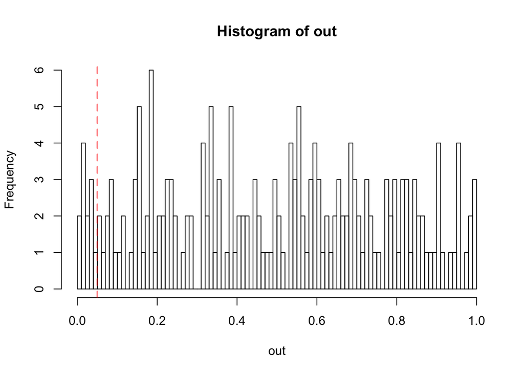

```r
mat.r <- matrix(data=rnorm(10000), nrow=50, ncol=200)

out <- apply(mat.r, 2, function(x) as.numeric(t.test(x, rnorm(50))[3]))

hist(out, breaks=100)
abline(v=0.05, col=rgb(1,0,0,0.5), lty=2, lwd=2)
```

## part 4

generate a function and a for loop that will plot each x value in the anscombe dataset vs. each y value. This will be 16 total plots. Display the correlation coefficient rounded to 3 decimal places as the title of each plot.